# Interactive plots

https://github.com/jtmccr1/DANG_5_31_2016

## Background

- We are interested in within host diversity of influenza virus (RNA genome).
- Translation : We do a lot of sequencing of viral swabs, and look for single nucleotide variants present at various frequencies *within a single person*

## Motivation : What is the accuracy of our method?

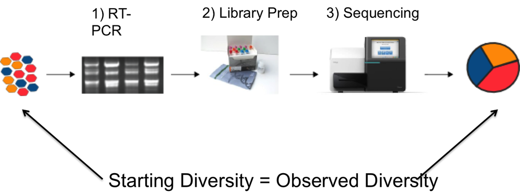

## Experimental set up

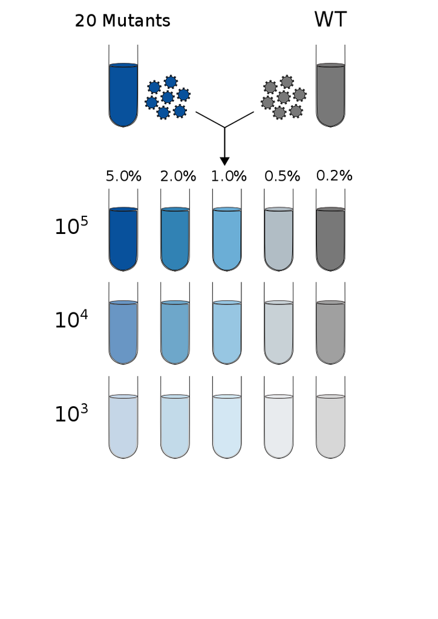

## Initial Accuracy

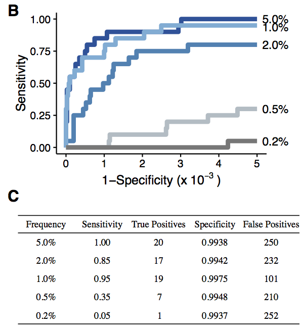

## Many variables

- Whether or not to include PCR duplicate reads
- Which p value correction method to use (Bonferroni or Benjamini Hochberg)
- Should the DeepSNV error model be a binomial model or a beta binomial.
- If beta binomial should the test be one sided or two sided (two sided is recommend with large amounts of PCR amplification)
- What p value threshold to use
- What mapping quality threshold to apply (if any)
- What Phred score threshold to apply (if any)
- What read position threshold should be applied (if any)
- What frequency threshold to apply (if any)
- Should only the coding regions be included in analysis
- Should the ends of the genomic segments be excluded from analysis (if so how much should be trimmed)

## Shiny app!

## What is Shiny

"A web application framework for R

Turn your analyses into interactive web applications

No HTML, CSS, or JavaScript knowledge required"

http://shiny.rstudio.com

## Example

## Shiny Application Architecture

Two chunks of code

1. UI - user interface - controls the layout of the app
2. Server - R script - code that runs the analysis and populates the plots
- Usually two separate files stored in the same directory
- Communicate through **input$** and **output$**

## ui.R

```r
bootstrapPage( # Page layout

  ## Input values
  selectInput(inputId = "n_breaks",  # name of the input  - for reference in server.R
      label = "Number of bins in histogram (approximate):", # label to be displayed on ui
      choices = c(10, 20, 35, 50), # Input specific options
      selected = 20), # starting value

  checkboxInput(inputId = "individual_obs",
      label = strong("Show individual observations"),
      value = FALSE),

  checkboxInput(inputId = "density",
      label = strong("Show density estimate"),
      value = FALSE),

  # Output plot from server.R
  plotOutput(outputId = "main_plot", height = "300px"),

  # Display this only if the density is shown
  conditionalPanel(condition = "input.density == true",  # An extra conditional panel
    sliderInput(inputId = "bw_adjust", # name of the input  - for reference in server.R
        label = "Bandwidth adjustment:", # label to be displayed on ui
        min = 0.2, max = 2, value = 1, step = 0.2) # Input specific options with starting value
  )

)
```

## selectInput

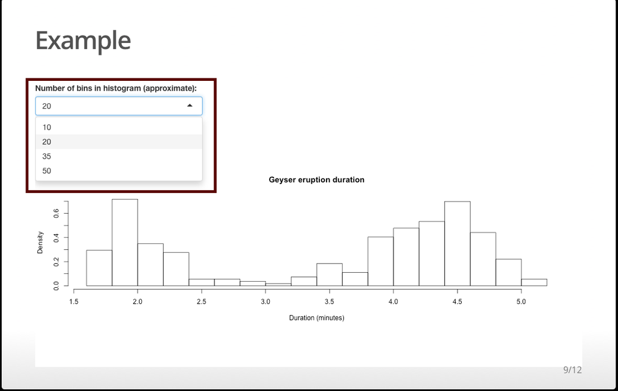

```r
  ## Input values
  selectInput(inputId = "n_breaks",  # name of the input  - for reference in server.R
      label = "Number of bins in histogram (approximate):", # label to be displayed on ui
      choices = c(10, 20, 35, 50), # Input specific options
      selected = 20), # starting value
```

## checkboxInput

```r
  ## Input values
  checkboxInput(inputId = "individual_obs",
      label = strong("Show individual observations"),
      value = FALSE),
```

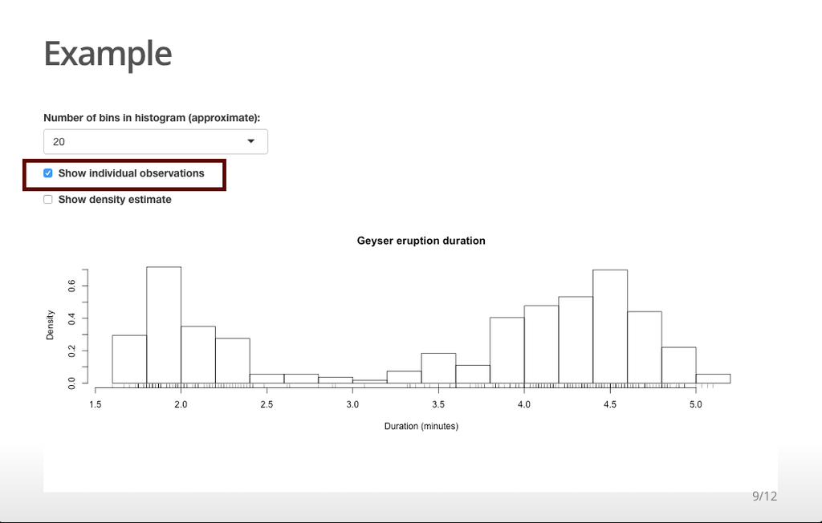

## Conditional sliderInput

```r
  checkboxInput(inputId = "density",
      label = strong("Show density estimate"),
      value = FALSE),
  # Display this only if the density is shown
  conditionalPanel(condition = "input.density == true",  # An extra conditional panel
    sliderInput(inputId = "bw_adjust", # name of the input  - for reference in server.R
        label = "Bandwidth adjustment:", # label to be displayed on ui
        min = 0.2, max = 2, value = 1, step = 0.2) # Input specific options with starting value
  )
```

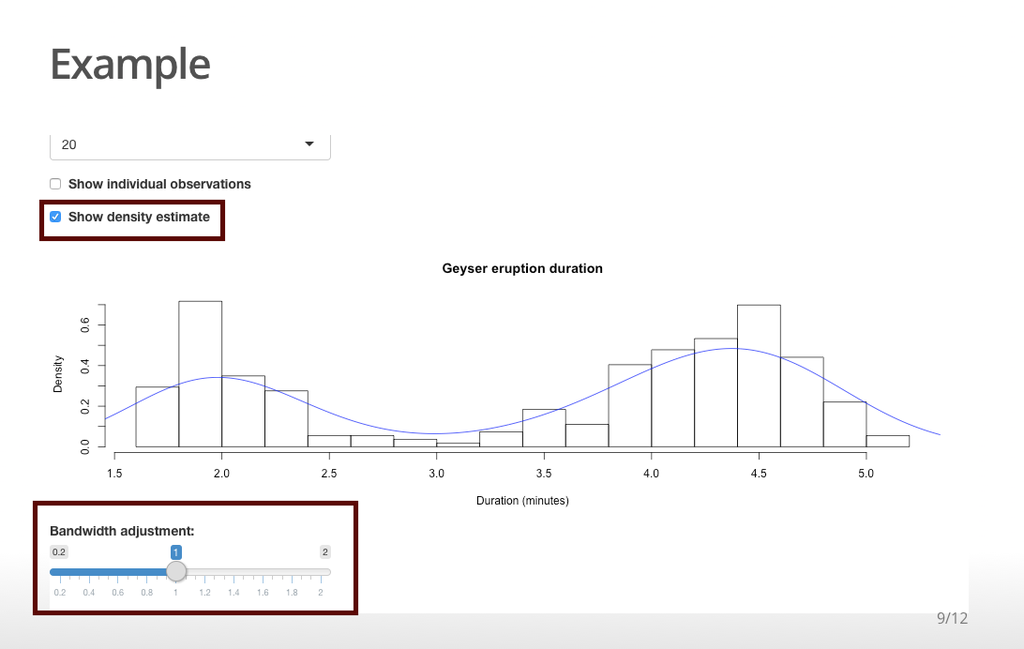

## Basic inputs

## Basic outputs

| Command | Produces |
| --- | --- |
| htmlOutput | raw HTML |
| imageOutput | image |
| plotOutput | plot |
| tableOutput | table |
| textOutput | text |
| uiOutput | raw HTML |
| verbatimTextOutput | text |

## server.R

```r
function(input, output) {
      output$main_plot <- renderPlot({ # populates plotOutput(outputId = "main_plot", height = "300px")

    hist(faithful$eruptions,
      probability = TRUE,
      breaks = as.numeric(input$n_breaks), # from - selectInput(inputId = "n_breaks",
      xlab = "Duration (minutes)",
      main = "Geyser eruption duration")

    if (input$individual_obs) { # from - checkboxInput(inputId = "individual_obs",
      rug(faithful$eruptions)
    }

    if (input$density) { # from checkboxInput(inputId = "density",
      dens <- density(faithful$eruptions,
          adjust = input$bw_adjust)     # from - conditionalPanel(condition = "input.density == true",
            lines(dens, col = "blue")   #         sliderInput(inputId = "bw_adjust",

    }

  })
}
```

## Building reactive outputs

```r
 reactive.df<-reactive({
   ## code that involves some input$ that will be rerun each time the input changes
 })
```

| Command | Produces |
| --- | --- |
| renderImage | images (saved as a link to a source file) |
| renderPlot | plots |
| renderPrint | any printed output |
| renderTable | data frame, matrix, other table like structures |
| renderText | character strings |
| renderUI | a Shiny tag object or HTML |

## Server.R - another look

```r
function(input, output) {
   output$main_plot <- renderPlot({ # populates plotOutput(outputId = "main_plot", height = "300px")
    hist(faithful$eruptions,
      probability = TRUE,
      breaks = as.numeric(input$n_breaks), # from - selectInput(inputId = "n_breaks",
      xlab = "Duration (minutes)",
      main = "Geyser eruption duration")

    if (input$individual_obs) { # from - checkboxInput(inputId = "individual_obs",
      rug(faithful$eruptions)
    }

    if (input$density) { # from checkboxInput(inputId = "density",
      dens <- density(faithful$eruptions,
          adjust = input$bw_adjust)     # from - conditionalPanel(condition = "input.density == true",
            lines(dens, col = "blue")   #         sliderInput(inputId = "bw_adjust",

    }

  })
}
```

## My Shiny app - ui.R

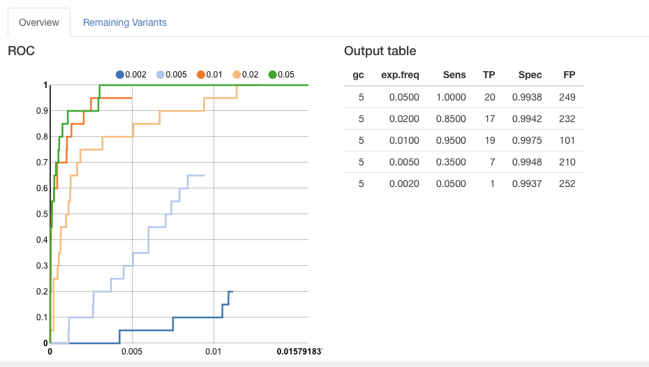

## My Shiny app - ui.R

```r
shinyUI(fluidPage(
  titlePanel("Benchmarking variant caller"), # Main title
  tabsetPanel( # make mulitple tabs

      tabPanel("Overview", #first tab title
        fluidRow( # split first tab by fluidRows (must sum to 12)
        column(6,  # This makes a column that takes up half the page
               h4("ROC"), # title
               showOutput("myChart", "nvd3")), # display rchart output
        column(6, # the other half
               h4("Output table"),
               tableOutput('table'))
      ),
      hr(), # horizontal line
```

## ui.R - Inputs

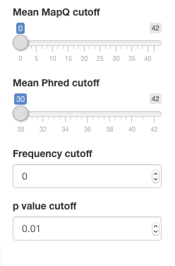

## ui.R Inputs

```r
fluidRow(
        column(3,     # Here I have 4 columns of equal width 3 X 4 =12
               sliderInput(inputId = "MapQ",  # slider input for MapQ
                            label = "Mean MapQ cutoff",
                            min=0,max=42,value=0),
               sliderInput(inputId = "Phred",
                           label = "Mean Phred cutoff",
                           min=30,max=42,value=30),

               numericInput(inputId = "freq.var",  # numerical input for frequency cutoff
                            label = "Frequency cutoff",
                            value=0),
               numericInput(inputId = "p.val",
                            label = "p value cutoff",
                            value=0.01)
        ),
```

## ui.R Second tab

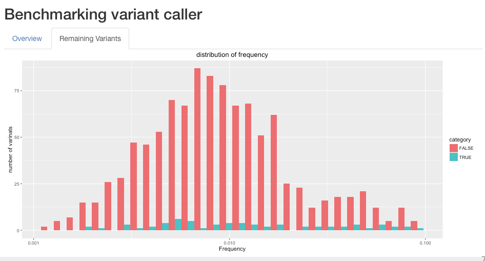

## ui.R Second tab

```r
tabPanel("Remaining Variants", # The second tab with graphs of the remaining variants
             fluidRow(
               column(12, # only 1 column here
                      #plotOutput("samp.dis"),
                      plotOutput("freq"),
                      plotOutput("mean.pos"),
                      plotOutput("mean.qual")
                      #plotOutput("mean.mapq"),
                      #plotOutput("position")

                )
             )
    )
```

## server.R - reading in data

```r
shinyServer(function(input, output) {
  dataInput<-reactive({  #### changes to data used ##########
    criteria<-paste0(input$dups,".*",input$method,".*",input$disp,".*","sum.csv$")
    file<-list.files(path = "~/Desktop/benchmarking_shiny/20_mut_data_set/processed_data",pattern = criteria,full.names = T)
    print(file)

    sum.df.raw<-read.csv(file,comment.char='#',stringsAsFactors = F)
    print(names(sum.df.raw))
    return(sum.df.raw)
  })
 data.c<-reactive({
    sum.df<-dataInput()
    if(input$coding==T){

      sum.df<-ddply(sum.df,~chr,coding.cut)
      return(sum.df)
    }else{
      return(sum.df)
    }
  })
```

## server.R - subsetting and ROC curve

```r
output$myChart <- renderChart2({
    sum.df<-data() # get data
    possible_vars<-possible.vars() # get possible_vars from reactive
    #subset data based on input
    cut.df<-subset(x=sum.df,MapQ>input$MapQ & Phred>input$Phred & gc==input$gc_roc & freq.var>input$freq.var& Read_pos<=input$pos[2] & Read_pos>=input$pos[1]& exp.freq %in% input$exp.freq)
    h.roc.df<-hiseq.roc(cut.df,20,possible_vars,">") # make ROC data frame
    #format data frame for plotting
    r_plot<-h.roc.df[order(h.roc.df$adj.specificity,decreasing = T),]
    r_plot<-mutate(r_plot,FDR=1-adj.specificity,threshold=format(threshold,scientific=T,digits=3))
    r_plot<-mutate(r_plot, gc = paste0("10^",sub(pat,"\\1",samp)))
    print(head(r_plot))

    #### make rchart ####
    rp <- nPlot(adj.sensitivity~FDR, group=c("exp.freq"), data = r_plot, type = "lineChart")
    rp$params$width = 450
    rp$params$height = 450
    rp$chart(forceX = c(0,0.005))
    rp$chart(forceY = c(0,1))
    rp$chart(tooltipContent = "#! function(key, x, y, e){
  return '<b>P=</b>: ' + e.point.threshold +
  '<b> FP</b>: '+e.point.FP+ '<b> TP</b>: '+e.point.TP
} !#")
    rp$yAxis( axisLabel = "Sensitivity" )
    rp$xAxis( axisLabel = "1-Specificity")
    rp
  })
```

## Shiny

- Straightforward means of producing interactive graphs using only R code
- No HTML,css,javascript required
- Allows one to interact with the data on all levels
- Requires an active R session
- Great tutorials available
- Well documented

## Other means of interactivity in R

- Produce interactive HTML plots that can stand alone - No R session needed
- Less powerful than Shiny

## rcharts

- R code => javascript charts
- Support base and lattice style plots
- Easy to share/embed
- OK documentation -http://rcharts.io

## Example

```r
library(rCharts)
hair_eye_male <- subset(as.data.frame(HairEyeColor), Sex == "Male")
n1 <- nPlot(Freq ~ Hair, group = "Eye", data = hair_eye_male, type = "multiBarChart")
n1
```

[interactive chart not shown]

## Plotly

- My new favorite
- Very easy to plot ggplot2 style plots
- Well documented

## Plotly example

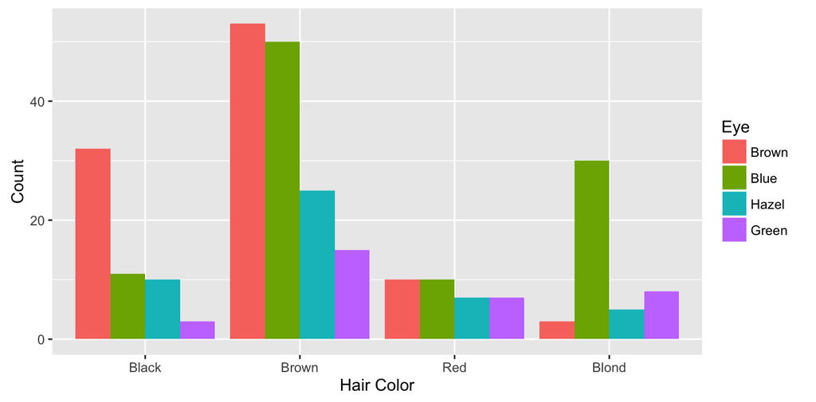

```r
require(plotly)
require(ggplot2)
hair_eye_male <- subset(as.data.frame(HairEyeColor), Sex == "Male")
example<-ggplot(hair_eye_male,aes(y=Freq,x=as.factor(Hair),fill=Eye))+geom_bar(stat="identity",position='dodge')+xlab("Hair Color")+ylab("Count")

example
```

## Plotly example (cont.)

```r
ggplotly(example)
```

[interactive chart not shown]

## In conclusion

1. Shiny
- Very powerful
- Alter all aspects of data and plots
- Well documented
- Requires an active R session
1. rCharts & Plotly
- Less powerful
- Provide a different form of interactivity
- Less documented but getting there
- produce stand alone html

## Questions?

- https://github.com/jtmccr1/DANG_5_31_2016
- http://lauringlab.github.io/benchmarking_shiny/